# Exploratory Analysis

## Project title

EMS Response Times and Traffic Fatalities

### Authors

- Runxin Shi, rshi3@uw.edu
- Qin Deng, qdeng2@uw.edu
- Caleb Lykken, Lykken@uw.edu
- Tyler Ramos, tr206@uw.edu

### Date

Winter 2022

### Abstract

Our main question is How does the emergency response time relate to the rate of fatalities? This question is important because it is useful information for public safety. To address the question, we will create data visualizations to easily show the relationship between emergency response times and the fatality rate. Also, we will try to make some analysis about under which conditions accidents are more likely to happen, like weather conditions and weekdays. By doing so, people can avoid some dangerous factors while driving, and the accident rate will decrease. We aim to create a safer driving environment and call for people’s attention on accidents through this project.

### Keywords

Traffic Fatalities, Emergency Response, Day of the Week, Weather

### Introduction

We are going to analyze the traffic fatalities in our group project. We will create some data visualization to help people compare and contrast data. Here are some examples of questions that our project can answer.

- Which day in the week that most traffic accidents happen?
- In what weather do the most traffic accidents happen?
- How does the emergency response time relate to the death rate of fatalities?
- In which state do most traffic accidents happen?
- How can people drive more safely under specific conditions?

A vast number of people each year lose their lives due to traffic fatalities. We aim to create a tool to help people get more information about traffic accidents. By properly visualizing the data from the dataset, people can get a clearer view of traffic fatalities around them. With these data, they can avoid some high-risk driving conditions which might easily cause dangerous accidents. Also, we wish that our website could call for the public’s attention. More concerns should be drawn to this part as the death number is huge. Moreover, it is the government’s responsibility that they should carry out some new policies or improvements which can reduce the rate of traffic fatalities. Overall, our project is to help people understand traffic fatalities more deeply.

### Related Work

In this project we are planning on using the data for the response time of emergency medical services(EMS). The main goal of EMS is to provide prompt medical care and transport to a medical facility. The response time of EMS is a critical factor in determining the outcome of a medical emergency. According to the National Fire Protection Association (NFPA) Standard 1710, the goal is to arrive on scene within 5 minutes, 90% of the time. In this case NFPA is using data from the District of Columbia in order to assess how fast the EMS response time is. (“Ems Response Time,” n.d.) Research has shown that response time can vary depending on the location of the medical emergency. In urban areas, the average response time is often shorter compared to rural and suburban areas due to the higher concentration of medical resources. However, in rural areas, the response time may be longer due to the lower population density and longer distances between the emergency scene and the nearest medical facility. A study conducted by JAMA Surgery found that rural EMS response times were longer than those in urban and suburban areas. The study concluded that it is important for rural areas to have a well-coordinated and well-equipped EMS system to provide prompt medical care and transport to those in need. The results of this study highlight the importance of continuous improvement and investment in EMS systems to ensure that all individuals have access to timely medical care.(Mell et al., 2017) Finally for Source 1 they talk more about EMS times in King County and overall emergency service related things such as the type of calls and they also check what percent arrives before certain time thresholds. Overall, the response time of EMS is a crucial factor in determining the outcome of a medical emergency and should be continuously monitored and improved. Investing in and improving EMS systems is essential in ensuring that all individuals have access to prompt medical care during medical emergencies.

Annotations: “Emergency Medical Services (EMS).” Emergency Medical Services (EMS) - King County,https://kingcounty.gov/~/media/depts/health/emergency-medical-services/documents/reports/2022-EMS-Annual-Report.ashx?la=en “Ems Response Time.” EMS Response Time, https://fems.dc.gov/page/ems-response-time#:~:text=NFPA%20Standard%201710%20establishes%20a,17%20for%20a%20detailed%20description). Mell, Howard K, et al. “Emergency Medical Services Response Times in Rural, Suburban, and Urban Areas.” JAMA Surgery, U.S. National Library of Medicine, 1 Oct. 2017, https://www.ncbi.nlm.nih.gov/pmc/articles/PMC5831456/.

### The Dataset

We found the 2015 traffic fatalities data data from Kaggle 2015 Traffic Fatalities but it originally came from the U.S. Department of Transportation The national highway traffic safety collected this data. They generate their data by using a scoring method that comes from a interim identification and prioritization process. The department of transportation collected this data to help find ways to prevent these tragedies. They made it available to the public so that researchers and data scientists could make solutions to the mass amount of fatalities that happen due to car crashes. There are 32166 observations in the data. The observations cover most of the crashes that happened in 2015 in all of the states including territories of the united states. There are 52 features in the data, the features include the state , time city and exact coordinates of the accident, it also has a lot of specific information about what happened when the crash happened. Most importantly they have the time it took for an ambulance to arrive to the site after they were notified. We will be focusing on the EMS response we need to keep an eye out for any injustice that is recorded in this dataset. Possible limitations in this data set are they don’t give the exact details about the people in the crash, like their background or where they were going. These details could fill many gaps in the dataset. They are not available because the department of transportation decided to keep the identity’s of the victims anonymous.

### Implications

For technologists, the emergency response time is an opportunity to create and implement more efficient systems for dispatch and communication between first responders, hospitals, and patients. This can involve developing new technologies, such as mobile apps and real-time location tracking systems, to improve the speed and accuracy of emergency response.

For designers, the emergency response time is an important consideration when designing and implementing public safety infrastructure, such as emergency call centers, road networks, and urban planning. The goal is to ensure that emergency services can reach patients in a timely manner and provide the necessary care.

For policymakers, research on emergency response time can inform the development of policies and regulations aimed at improving emergency response times. This could include minimum response time standards, investment in emergency services and infrastructure, and policies to address issues such as traffic congestion and emergency personnel shortages. By understanding the factors that contribute to emergency response times, policymakers can make data-driven decisions to improve the effectiveness of emergency services and ensure that patients receive the care they need in a timely manner. Additionally, they may also create regulations and standards to ensure a minimum level of response time and quality of care for patients.

### Limitations & Challenges

The limitation and challenges that come with this dataset is that not every single car fatality was recorded. There are many traffic fatalities that are in rural areas or that are in small communities that never get recorded. When there is a recording issue like this it is hard to be one hundred percent sure that our data is accurate. Another challenge is that the data set is encrypted with many codes for certain pieces of data, we have access to the code book so we will have to do a lot of cleaning of the data to be able to better understand it. The codebook is very long and can be confusing at times, for example the states are numbered in the data set and are in alphabetical order including some US territories. Even though these limitations and challenges may be hard to deal with, they are not detrimental to our final project.

### Summary Information

```
##   STATE ST_CASE VE_TOTAL VE_FORMS PVH_INVL PEDS PERNOTMVIT PERMVIT PERSONS
## 1     1   10001        1        1        0    0          0       1       1
## 2     1   10002        1        1        0    0          0       1       1
## 3     1   10003        1        1        0    0          0       2       2
## 4     1   10004        1        1        0    0          0       1       1
## 5     1   10005        2        2        0    0          0       2       2
## 6     1   10006        1        1        0    0          0       2       2
##   COUNTY CITY DAY MONTH YEAR DAY_WEEK HOUR MINUTE NHS RUR_URB FUNC_SYS RD_OWNER
## 1    127    0   1     1 2015        5    2     40   0       1        3        1
## 2     83    0   1     1 2015        5   22     13   1       1        1        1
## 3     11    0   1     1 2015        5    1     25   0       1        3        1
## 4     45    0   4     1 2015        1    0     57   0       1        4        1
## 5     45 2050   7     1 2015        4    7      9   0       2        3        1
## 6    111    0   8     1 2015        5    9     59   0       1        5        2
##   ROUTE  TWAY_ID          TWAY_ID2 MILEPT LATITUDE  LONGITUD SP_JUR HARM_EV
```

[output cut: 27 more lines]

```
##    States DAY MONTH YEAR DAY_WEEK LATITUDE  LONGITUD Weather ARR_HOUR ARR_MIN
## 1 Alabama   1     1 2015        5 33.87865 -87.32533   Clear        2      58
## 2 Alabama   1     1 2015        5 34.91044 -86.90871  Cloudy       22      20
## 3 Alabama   1     1 2015        5 32.14201 -85.75846   Clear        1      45
## 4 Alabama   4     1 2015        1 31.43981 -85.51030  Cloudy        1      15
## 5 Alabama   7     1 2015        4 31.31933 -85.51510   Clear        7      16
## 6 Alabama   8     1 2015        5 33.43849 -85.38927   Clear       10      17
##   DRUNK_DR FATALS PERSONS
## 1        1      1       1
## 2        0      1       1
## 3        1      1       2
## 4        1      1       1
## 5        0      1       2
## 6        0      1       2
```

```
## [1] "7"
```

The first summary information is in which weather conditions most accidents happen in each state. We want to analyze how accidents happen according to the weather traits in each state. We find out that under rainy weather there are 2401 cases. The second summary information ranks the number of accidents for states. By doing so, we can see which state has the most cases and find the reason behind it. We see that Texas gets the most cases. The third summary is that we want to determine which weekdays most accidents happen. The data shows that 7 get the most cases. The fourth piece of information is the accidents that involve drunk drivers. The analysis shows that Texas receives the most drunk-driver-related cases. The last summary information is the average EMS arrival time for each state. From the table, New Jersey shows the shortest arrival time, 9.09 hours. And Illinois reflects the longest arrival time, which is 16.97 hours. However, the fastest arrival time is still long for emergency patients.

### Table

```
##                  States Number_of_Cases Number_of_Cases_in_Rainy_Day
## 1               Alabama             783                           79
## 2                Alaska              60                            5
## 3               Arizona             810                           22
## 4              Arkansas             472                           55
## 5            California            2925                           74
## 6              Colorado             506                           15
## 7           Connecticut             253                           17
## 8              Delaware             122                           12
## 9  District of Columbia              23                            1
## 10              Florida            2699                          137
## 11              Georgia            1327                          171
## 12               Hawaii              86                            7
## 13                Idaho             198                            4
## 14             Illinois             914                           65
```

[output cut: 141 more lines]

### Chart 1

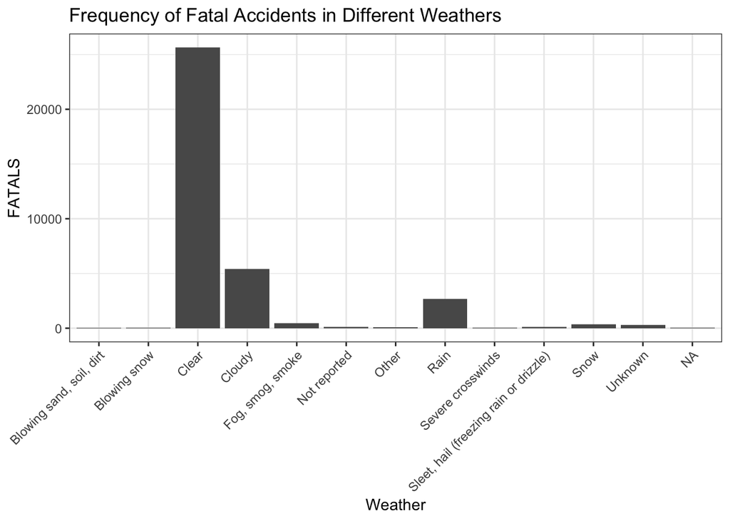

This is because weather conditions may have an impact on traffic accidents, which can lead to more injuries or fatalities. For example, adverse weather conditions may lead to slippery roads, poor visibility, and poor vehicle control, which may increase the risk of traffic accidents. Therefore, analyzing the link between the number of accident deaths and injuries and weather helps us to better understand the impact of weather conditions on traffic accidents and take appropriate measures to reduce the incidence of traffic accidents and decrease the number of casualties. At the same time, through the table, we found that it is true that the weather such as cloudy and rainy weather will increase the number of deaths and injuries in accidents. However, most of the serious injuries are during clear weather, which proves that the main reason for the number of serious injuries is not the weather.

### Chart 2

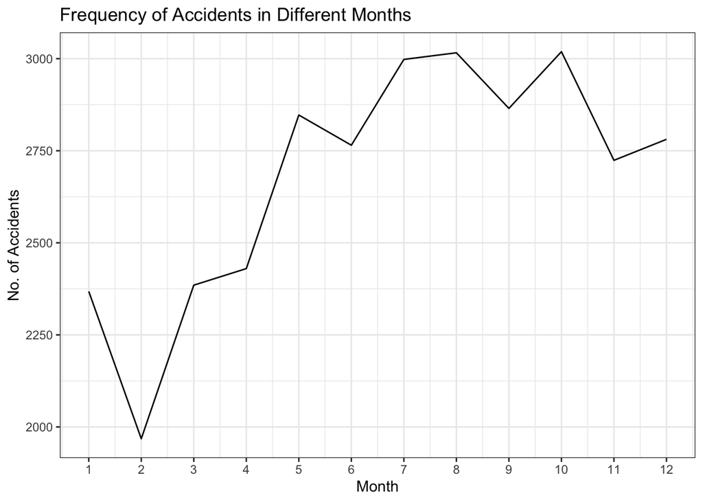

### Chart 3

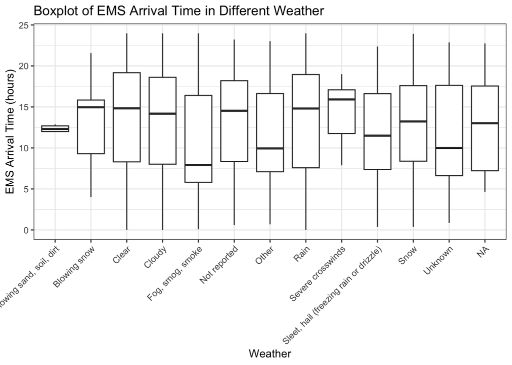